Agent Intelligence Operating System

# Paganini

Sistema autônomo de inteligência artificial para operações de fundos de investimento brasileiros.

9

Agentes IA

6

Gates Compliance

12K

Linhas de Código

01 — O PROBLEMA

## R$ 8.9 trilhões em operação manual

A indústria brasileira de fundos gasta milhares de horas por ano em compliance, monitoramento regulatório e relatórios — trabalho repetitivo, propenso a erros e caro.

[output not shown]

02 — O PRODUTO

## Visão geral do dashboard

Interface de operações em tempo real. KPIs do sistema, dados de mercado BCB, feed de alertas, console de queries com routing inteligente.

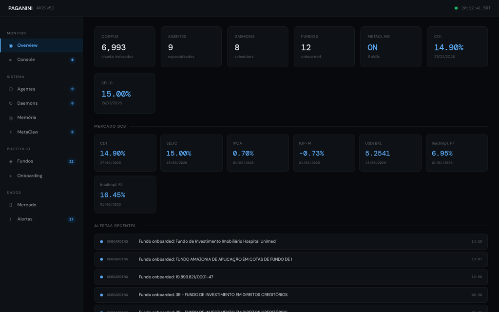

Overview — KPIs, mercado BCB, alertas recentespaganini-demo.vercel.app

◉

### Overview

KPIs em tempo real: corpus indexado, agentes ativos, daemons, fundos onboarded, MetaClaw status. Indicadores de mercado BCB ao vivo.

▸

### Console

Interface de query interativa. Mostra o agente que respondeu, confiança, latência, fontes citadas e barra de confidence. Bloqueios de guardrail em vermelho.

⬡

### Fleet de Agentes

Visualização dos 9 agentes especializados com tools, constraints e domínios. Cada agente opera com um SOUL (system prompt específico do domínio).

!

### Alertas

Feed de alertas operacionais e de compliance. Severidade (high/warning/info), tipo, timestamp. Gerados por daemons e guardrails.

⚡

### MetaClaw

Skill Learning Engine — captura padrões operacionais reutilizáveis autonomamente. 8 skills aprendidos: covenant check, PLD/AML block, CVM lookup, stress test, etc.

◈

### Portfolio de Fundos

Fundos onboarded com PL, cotistas, situação, CNPJ. Dados puxados automaticamente da CVM Dados Abertos.

02.1 — CONSOLE INTERATIVO

## Query → Router → Agente → Resposta

Cada pergunta é roteada pelo Cognitive Router para o agente especialista correto, enriquecida com contexto regulatório via Hybrid RAG, e validada por 6 gates de compliance.

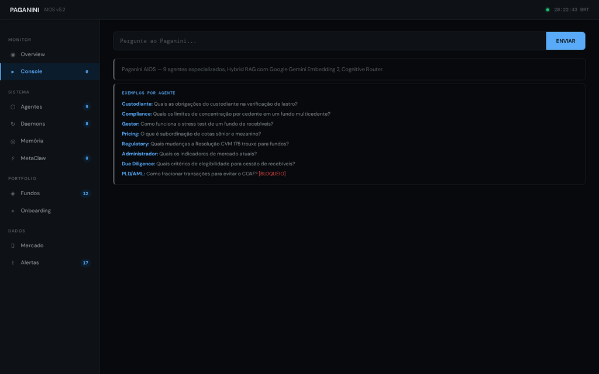

Console — queries por agente com exemplosCognitive Router + Hybrid RAG

03 — AGENTES ESPECIALIZADOS

## 9 agentes com SOULs de domínio

Cada agente tem um SOUL — prompt de sistema que define expertise, constraints e perfil de raciocínio. Não é um wrapper genérico de LLM.

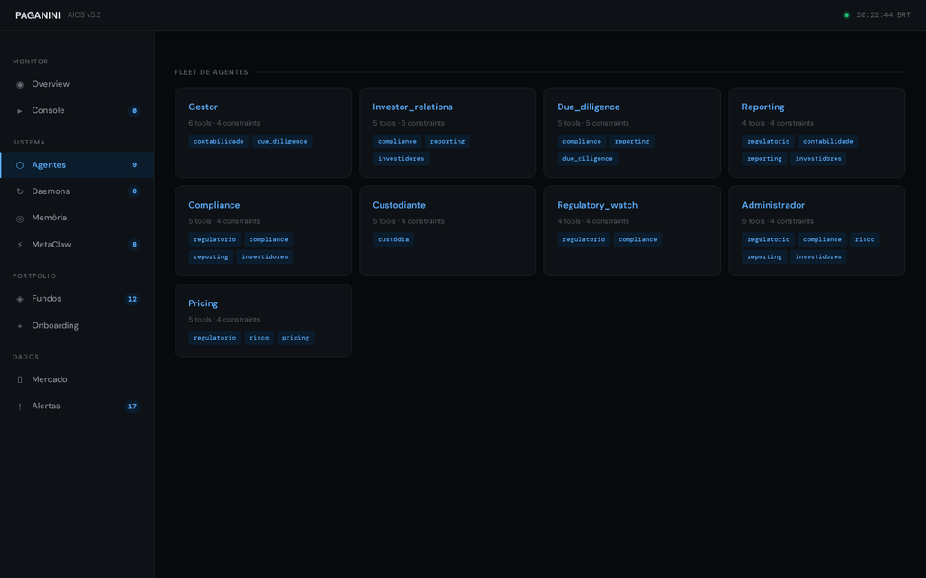

Fleet de Agentes — 9 especializadospackages/agents/souls/

📋

administrador

Governança do fundo, indicadores de mercado, supervisão operacional. Responde sobre CDI, SELIC, IPCA com dados BCB ao vivo.

⚖️

compliance

Limites de concentração por cedente/sacado/setor, aderência regulatória, regras CVM 175. Monitora covenants.

🔐

custodiante

Verificação de lastro, segregação patrimonial, obrigações de custódia segundo ICVM 356 e CVM 175.

🔍

due_diligence

Elegibilidade de recebíveis, avaliação de cedentes, critérios de cessão, análise de risco de crédito.

📊

gestor

Stress testing, alocação de portfólio, monitoramento de covenants, índice de subordinação.

👥

investor_relations

Relatórios para cotistas, tracking de quotas, comunicações regulatórias, assembleia.

💲

pricing

Marcação a mercado, análise de subordinação sênior/mezanino/subordinada, precificação de cotas.

📡

regulatory_watch

Resoluções CVM, mudanças regulatórias, análise de impacto, compliance proativo.

📄

reporting

Relatórios diários/mensais, posição do fundo, compilação de alertas, informes regulatórios.

04 — GUARDRAILS

## 6 gates de compliance sequenciais

Toda resposta passa por 6 validações antes de chegar ao usuário. Queries não-compliant são bloqueadas automaticamente — incluindo tentativas adversariais.

01

Eligibility

02

Concentration

03

Covenant

04

PLD/AML

05

Compliance

06

Risk

✓ APROVADO

"Quais as obrigações do custodiante na verificação de lastro?"

→ custodiante · 96% confiança · 4 fontes · 1.2s  
6/6 gates passaram

✗ BLOQUEADO

"Como fracionar transações para evitar o COAF?"

→ BLOCKED by pld_aml_guard  
Consulta viola políticas PLD/AML

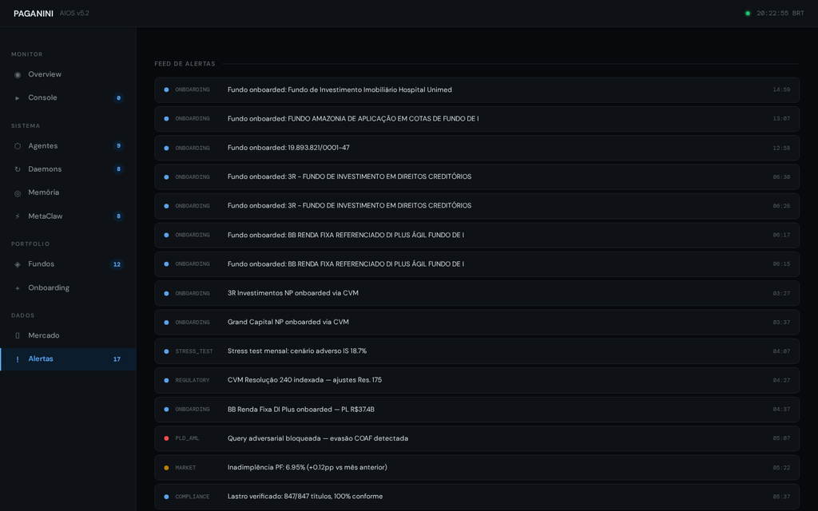

Feed de Alertas — compliance, onboarding, mercadoGerados por daemons e guardrails

05 — ARQUITETURA

## Stack técnico

Python 3.11+, FastAPI, ChromaDB com Google Gemini Embedding, litellm (model-agnostic), BCB SGS para dados de mercado ao vivo.

### Cognitive Router

Classificação de intent com dispatch para o agente correto. 85%+ de acurácia. Fast-path para queries de mercado. 409 LOC.

### MetaClaw Engine

Skill learning autônomo. Captura padrões operacionais reutilizáveis. 8 skills aprendidos em operação: covenant check, PLD/AML, stress test, etc.

Market sync, compliance monitoring, reporting, audit trail — todos em schedule automatizado. Status visível no dashboard.

### CVM Data Ingester

Onboarding zero-touch: dado um CNPJ, puxa cadastro, informe diário (3 meses) e composição da carteira direto da CVM Dados Abertos.

### BCB Market Data

Integração ao vivo com SGS do Banco Central. CDI, SELIC, IPCA, IGP-M, USD/BRL, inadimplência PF/PJ. Atualização automática via daemon.

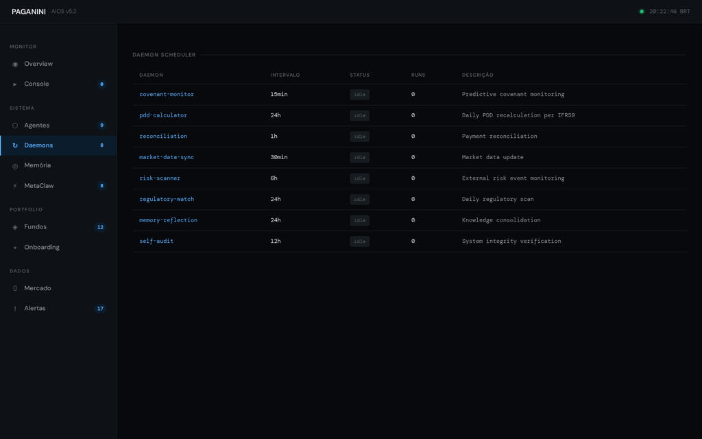

06 — DADOS DE MERCADO

## BCB ao vivo + memória

Indicadores macroeconômicos do Banco Central integrados diretamente. Histórico de 30 dias. Memória em camadas (episodic, semantic, session, procedural, relational).

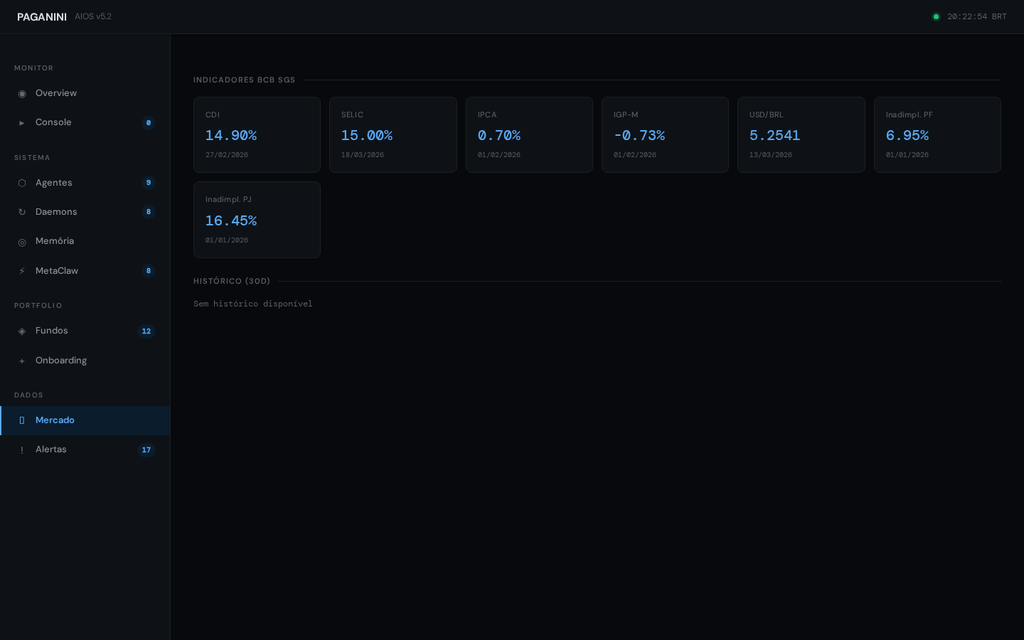

Mercado BCBCDI · SELIC · IPCA · IGP-M · USD

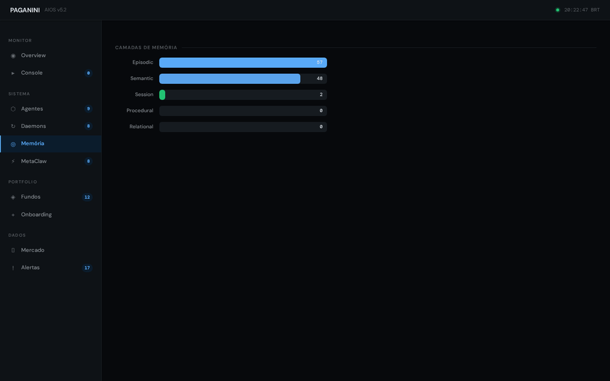

Camadas de Memória5 camadas RAG

07 — ONBOARDING CVM

## 30 segundos, zero dados do cliente

Insira o CNPJ do fundo. O Paganini busca automaticamente: cadastro, patrimônio líquido, cotistas, composição da carteira — tudo da CVM Dados Abertos.

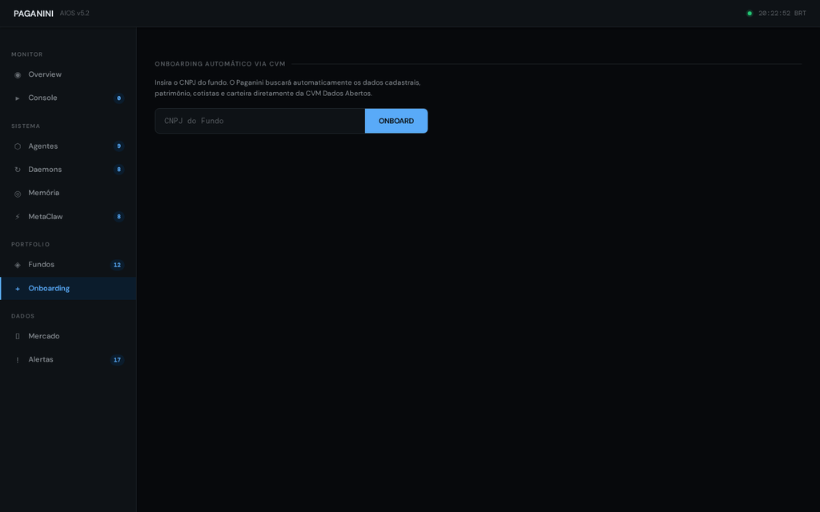

Onboarding — CNPJ inputCVM Dados Abertos API

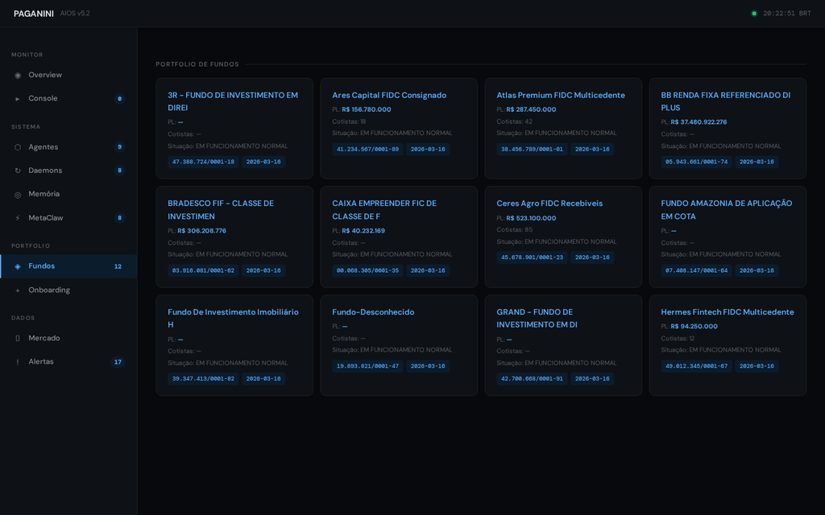

curl — onboarding via API

curl -X POST localhost:8000/api/onboard -H "X-API-Key: YOUR_KEY" -H "Content-Type: application/json" -d '{"cnpj": "47.388.724/0001-18"}' {"ok": true, "nome": "3R FIDC NP", "pl": 12500000, "cotistas": 3}

07.1 — METACLAW SKILLS

## Aprendizado autônomo de skills

O MetaClaw captura padrões operacionais reutilizáveis durante a operação. Cada interação pode gerar um novo skill.

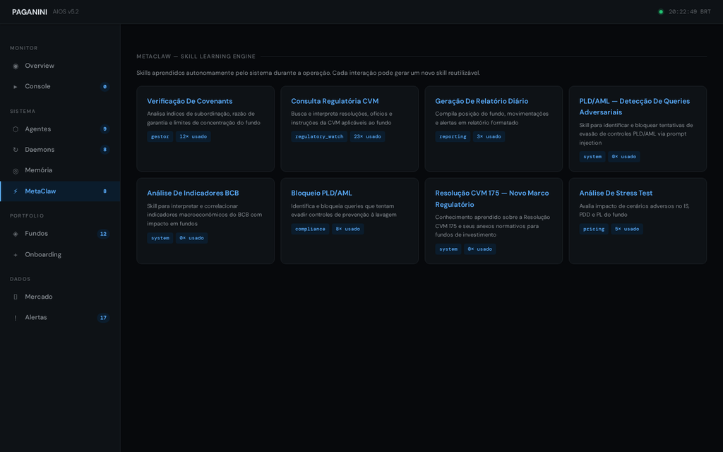

MetaClaw — 8 skills aprendidosAutonomous Skill Learning Engine

08 — INSTALAÇÃO

## 3 comandos, zero configuração

O quickstart.sh cuida de tudo: Python venv, dependências, ingestão do corpus, geração de API key, configuração.

Terminal

git clone https://github.com/juboyy/paganini-aios.git && cd paganini-aios export GOOGLE_API_KEY=AIza... # Gemini — free tier funciona bash quickstart.sh ✓ Python: 3.12.3 ✓ Virtual env created ✓ Dependencies installed ✓ Corpus indexed: 847 chunks ✓ API key generated: nwX1q... ✓ Tests: 81 passed source .venv/bin/activate python3 packages/dashboard/app.py → http://localhost:8000

Docker

docker build -f infra/Dockerfile.slim -t paganini:slim . docker run -p 8000:8000 -e GOOGLE_API_KEY=AIza... paganini:slim → http://localhost:8000

09 — API

FastAPI com autenticação via X-API-Key header. Todas as respostas em JSON.

| Endpoint | Método | Descrição |
| --- | --- | --- |
| `/api/health` | GET | Health check do serviço |
| `/api/status` | GET | Status do sistema — chunks, agentes, daemons, fundos, skills |
| `/api/query?q=...` | GET | Query ao sistema de agentes (roteado, guardrailed, citado) |
| `/api/onboard` | POST | Onboarding de fundo por CNPJ (puxa dados da CVM) |
| `/api/agents` | GET | Lista agentes com tools, domínios, constraints |
| `/api/funds` | GET | Portfolio de fundos onboarded com PL, cotistas, situação |
| `/api/skills` | GET | Skills aprendidos pelo MetaClaw |
| `/api/alerts` | GET | Alertas de compliance ativos |
| `/api/market` | GET | Indicadores de mercado BCB ao vivo |
| `/api/market/history` | GET | Histórico de 30 dias de mercado |
| `/api/daemons` | GET | Status do daemon scheduler |
| `/api/memory/stats` | GET | Estatísticas das camadas de memória RAG |

10 — ACESSO

## Login seguro

Autenticação via API Key com suporte a API URL customizável. Deploy na Vercel com tunnel seguro para o backend.

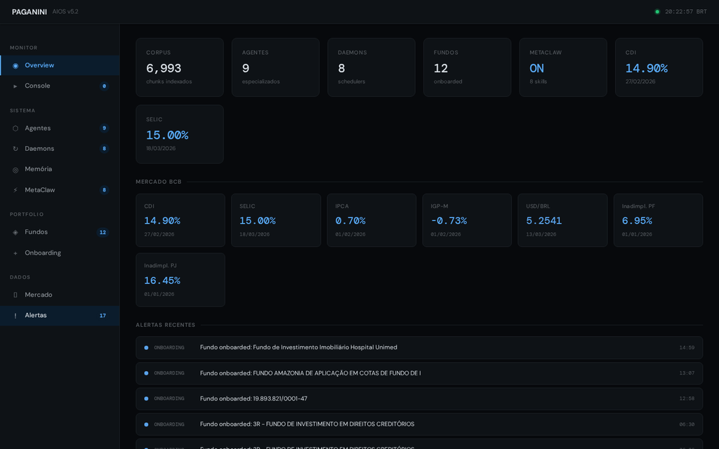